# IoslidesDemo

8/13/2020

## Introduction

Problem Statement: To understand personality differences between technologists and the general workforce.

Hypothesis to test: Mission Analysis and Enablement workers are similar in personality to the general workforce population.

## Background (1 of 2)

### Personality Assessment

This 75 question personality assessment aims to measure 15 underlying personality traits using similar measurements to the [Jackson Personality Inventory - Revised (JPI-R)](https://w8y7a2j5.stackpathcdn.com/wp-content/uploads/2015/03/JPI-R-Scales.pdf).

The JPI-R measures were selected due to the range of personality traits measured and inclusion of 7 measurements for “analytical” and “dependable,” traits previously reported in those performing highly technical work roles. This set of 15 measures has been useful in vocational counseling.

This *JPI-R proxy* consists of questions drawn from the public domain repository of personality questions (https://ipip.ori.org/).

## Background (2 of 2)

*Analytical*

- Complexity
- Breadth of Interest
- Innovation
- Tolerance

*Extroverted*

- Sociability
- Social Confidence
- Energy Level

*Emotional*

- Empathy
- Anxiety
- Cooperativeness

*Opportunistic*

- Risk Taking
- Social Astuteness

*Dependable*

- Organization
- Traditional Values
- Responsibility

## Education (n=19)

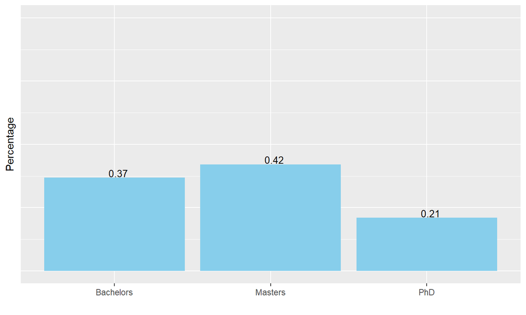

## Age

Median age is 54 years.

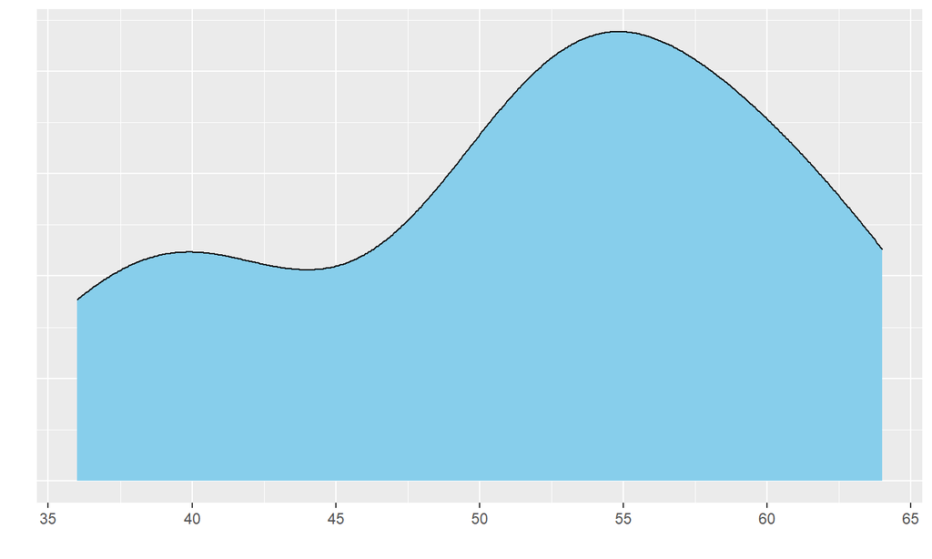

## Hobbies

[interactive chart not shown]

## Personality Results

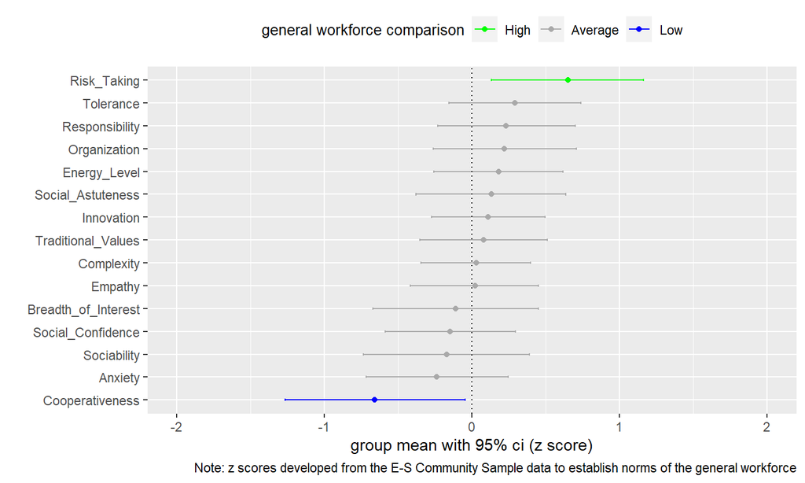

## Personality Results (2 of 2)

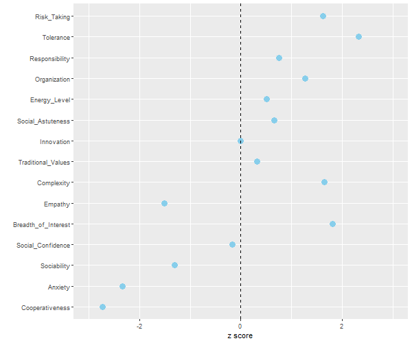

## Clustering Analysis

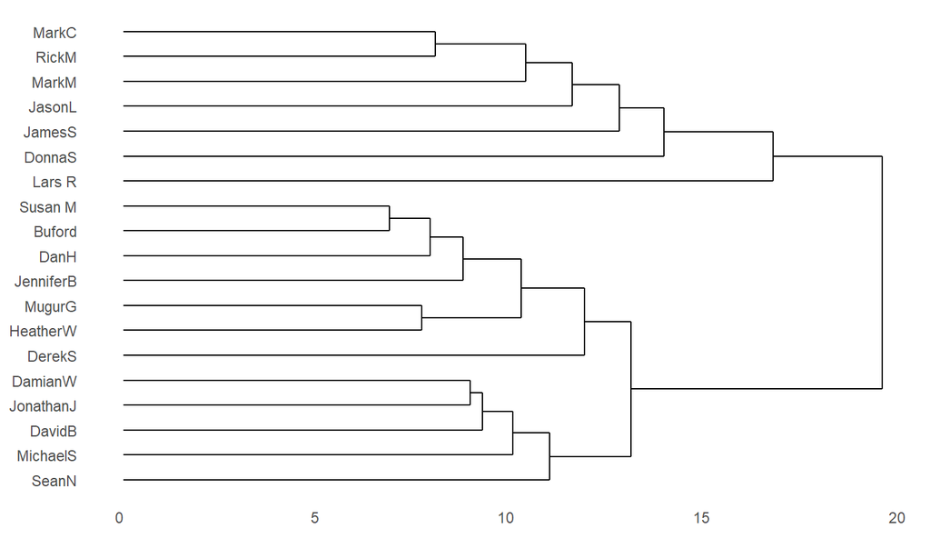

## Conclusions

Hypothesis to test: Mission Analysis and Enablement workers are similar in personality to the general workforce population.

What is your Conclusion: *Accept* the Null Hypothesis -or- *Reject* the Null Hypothesis?

## References

Douglas N. Jackson, Technical Manual: Jackson Personlaity Inventory - Revised, published by Sigma Assessment Systems, August 1994.

International Personality Item Pool, available at: https://ipip.ori.org/

R Core Team (2019). R: A language and environment for statistical computing. R Foundation for Statistical Computing, Vienna, Austria. URL https://www.R-project.org/.

Eugene-Springfield Community Sample, Harvard Dataverse, available at: https://dataverse.harvard.edu/dataverse/ESCS-Data

Full Presentation available at: https://mattdeloia.github.io/DemoOUAug20/

## Back-up: Gender Differences

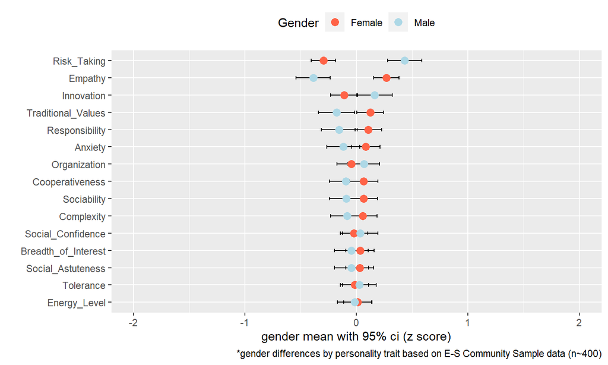

## Back-Up: Trait Descriptions (1 of 3)

Analytical

- Complexity: seeks intricate solutions to problems
- Breadth of Interest: interested in learing about a diversity of things
- Innovation: motivated to develop novel solutions to problems; values new ideas
- Tolerance: accepts people even though they may differ from oneself; welcomes dissent

## Back-Up: Trait Descriptions (2 of 3)

Emotional

- Empathy: tends to identify closely with other people and their problems
- Anxiety: tends to worry over inconsequential matters; apprehensive about the future
- Cooperativeness: is susceptible to social influence and group pressures; follows suit

Extroversion

- Sociability: eagerly join a varity of social groups; actively social
- Social Confidence: confident in dealing with others; shows presence in interpersonal situations
- Energy level: is active and spirited; does not tire easily; capable of intense work for long periods

## Back-Up: Trait Descriptions (3 of 3)

Opportunistic

- Social Astuteness: skillful at persuading others to achieve a particlular goal; occasionally seen as manipulative of others, but ordinarily diplomatic
- Risk Taking: enjoys gambling and taking a chance; willingly exposes self to situations with uncertain outcomes

Dependable

- Organization: makes effective use of time; not easily distracted
- Traditional Values: values traditional customs and beliefs; others may view individual as “old-fashioned”
- Responsibility: strong obligation to be honest and upright; an inflexibly conscience